# Econometria III Aula 5

Mestrado Profissional em Administração

Prof. Dr. Washington Santos da Silva

16/11/2026

## Programação da aula

### Aula anterior

- Modelos dinâmicos para dados em painel I
  - Dinâmica e Endogeneidade em Modelos para Dados em Painel
  - Visão Geral do Método dos Momentos
  - Visão Geral das Variáveis Instrumentais
  - Visão Geral do Método Generalizado dos Momentos (GMM)

### Hoje

- Modelos dinâmicos para dados em painel II
  - O problema: persistência em dados em painel
  - A tentativa com Efeitos Fixos e o Viés de Nickell
  - GMM em diferenças de Arellano e Bond (1991)
  - GMM em sistema de Blundell e Bond (1998)
  - Estrutura de decisão
  - Resumo

O problema: persistência em dados em painel

## Crescimento do PIB em 50 países (dados simulados)

### O crescimento do PIB deste ano depende do crescimento do ano passado? Se sim, como estimar essa persistência?

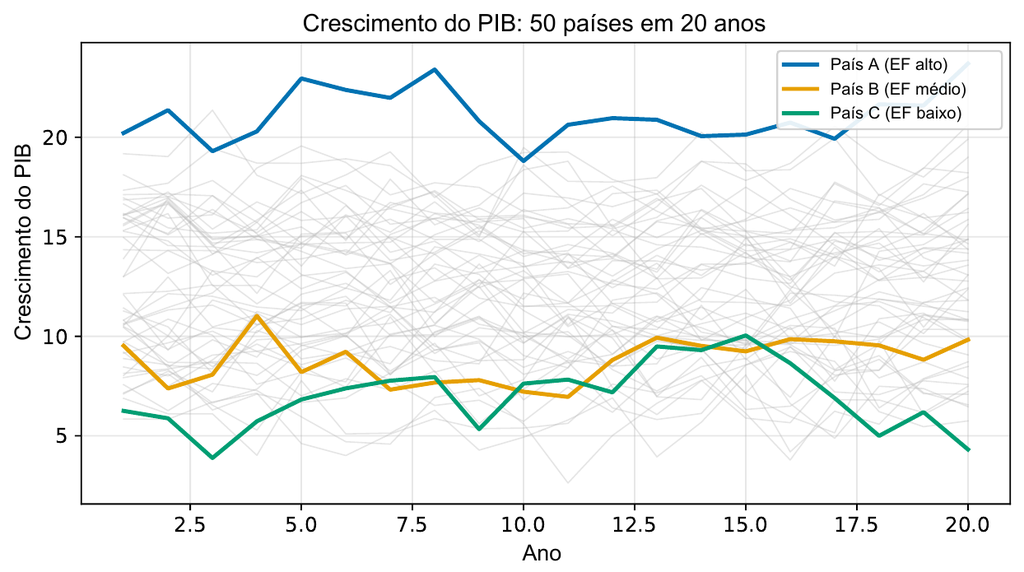

Figura 1: Trajetórias do crescimento do PIB de 50 países ao longo de 20 anos. Os países A, B e C ilustram a heterogeneidade individual não observada, representada por efeitos fixos altos, médios e baixos, que contribuem para diferenças sistemáticas nas taxas médias de crescimento entre países. As trajetórias também sugerem persistência temporal do crescimento dentro de cada país.

## Persistência:

### O Padrão

Duas características se destacam neste painel:

1. **Heterogeneidade entre países.** Características específicas dos países (instituições, geografia, cultura) podem contribuir para diferenças sistemáticas nas taxas médias de crescimento $\Longrightarrow$ heterogeneidade individual não observada, representada por $\alpha_i$.
2. **Persistência dentro dos países.** As trajetórias sugerem que o crescimento de um país em determinado ano está associado ao seu próprio crescimento no ano anterior $\Longrightarrow$ isso motiva a inclusão da variável dependente defasada $y_{i,t-1}$.

$\Longrightarrow$ Precisamos de um modelo que inclua **tanto efeitos fixos quanto uma variável dependente defasada**.

## O modelo dinâmico de painel

$$y_{it}=\rho\,y_{i,t-1}+\beta\,\mathrm{invest}_{it}+\alpha_i+\varepsilon_{it}$$

- $y_{it}$: crescimento do PIB do país $i$ no ano $t$;
- $y_{i,t-1}$: crescimento do ano passado (a variável dependente defasada);
- $\mathrm{invest}_{it}$: taxa de investimento (regressora exógena);
- $\alpha_i$: efeito fixo do país (não observado, invariável no tempo);
- $\varepsilon_{it}$: erro idiossincrático ($\mathrm{E}[\varepsilon_{it}]=0$, sem correlação serial).

O parâmetro $\rho$ mede a persistência: quanto do crescimento do ano passado se transmite para o seguinte. Se $|\rho|<1$, o efeito de um choque transitório se dissipa ao longo do tempo.

**Objetivo:** estimar $\rho$ consistentemente. Valor verdadeiro em nossa simulação: $\rho=0{,}40$.

## A relação defasada

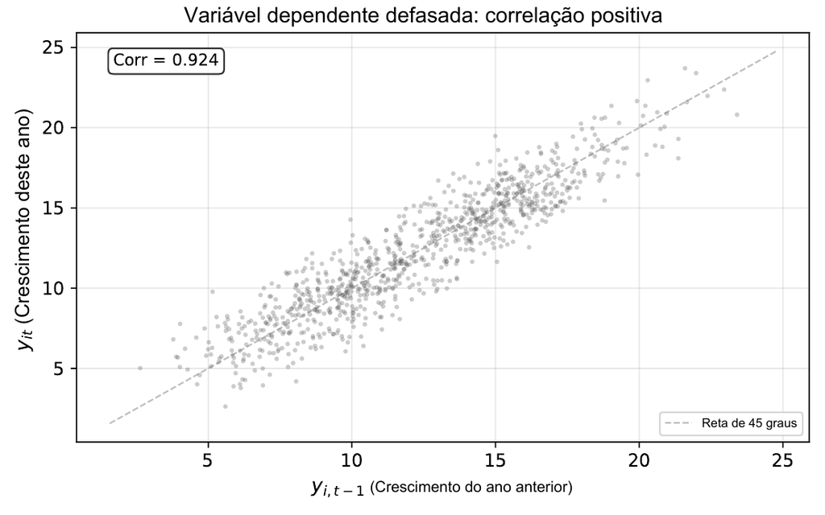

Figura 2: Crescimento atual e defasado do PIB: correlação de 0,924. Forte correlação positiva entre $y_{it}$ e $y_{i,t-1}$. Mas quanto é persistência verdadeira e quanto é determinado pelo $\alpha_i$ não observado?

## MQO ingênuo

### Basta regredir $y_{it}$ em $y_{i,t-1}$

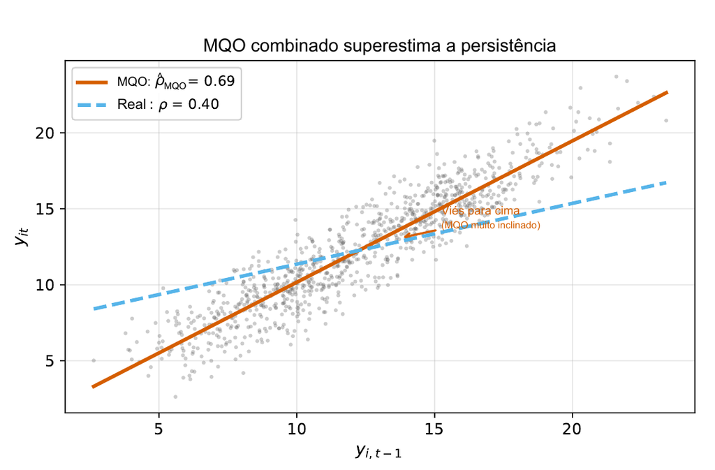

Figura 3: MQO combinado: superestimação da persistência. MQO estima $\hat\rho_{\mathrm{MQO}}\approx0{,}69$. O $\rho$ verdadeiro é $0{,}40$. Por que a superestimação?

## Por que MQO falha?

### Viés por variável omitida

Pense em dois países:

- O **país A** tem instituições fortes ($\alpha_i$ alto). Seu crescimento tende a ser mais elevado, em média. Tanto $y_{i,t-1}$ quanto $y_{it}$ tendem a ser maiores.
- O **país C** tem instituições fracas ($\alpha_i$ baixo). Seu crescimento tende a ser menor, em média. Tanto $y_{i,t-1}$ quanto $y_{it}$ tendem a ser menores.

Ao combinar os países, o MQO capta tanto a **persistência dentro de cada país** quanto as **diferenças permanentes entre países**.

O problema é que $y_{i,t-1}$ depende de $\alpha_i$, que foi omitido da regressão. Portanto, no exemplo:

$$\operatorname{Cov}(y_{i,t-1},\alpha_i)\neq 0.$$

Assim, a heterogeneidade individual não observada constitui uma fonte de endogeneidade.

$\rightarrow$ Nesta simulação, o MQO combinado superestima a persistência: $\hat\rho_{\mathrm{MQO}}\approx 0{,}69$, enquanto $\rho=0{,}40$.

A tentativa com Efeitos Fixos e o Viés de Nickell

## Efeitos fixos

### A solução natural?

A transformação *within* elimina $\alpha_i$ subtraindo as médias individuais:

$$\underbrace{y_{it}-\bar y_i}_{\ddot y_{it}}
=\rho\,\underbrace{(y_{i,t-1}-\bar y_{i,-1})}_{\ddot y_{i,t-1}}
+\beta\,\ddot{\mathrm{invest}}_{it}
+\underbrace{(\varepsilon_{it}-\bar\varepsilon_i)}_{\ddot\varepsilon_{it}}$$

As médias $\bar y_i$ e $\bar y_{i,-1}$ referem-se, respectivamente, a $y_{it}$ e $y_{i,t-1}$ nas observações utilizadas na estimação.

Não há mais $\alpha_i$. Problema resolvido?

Não exatamente. Há um problema sutil com a remoção das médias quando temos uma variável dependente defasada.

## Viés de Nickell

### Remover as médias cria correlação

A variável defasada transformada $\ddot y_{i,t-1}=y_{i,t-1}-\bar y_{i,-1}$ está correlacionada com o erro transformado $\ddot\varepsilon_{it}=\varepsilon_{it}-\bar\varepsilon_i$.

**Exemplo concreto.** Suponha que $\varepsilon_{i,5}$ seja um grande choque positivo.

- O choque eleva $y_{i,5}$, que também entra na média das defasagens $\bar y_{i,-1}$. Portanto, essa média **aumenta**.
- Como $y_{i,4}$ não foi afetado pelo choque, $\ddot y_{i,4}=y_{i,4}-\bar y_{i,-1}$ **diminui**.
- Enquanto isso, $\ddot\varepsilon_{i,5}=\varepsilon_{i,5}-\bar\varepsilon_i$ **aumenta**.

$\Longrightarrow$ O choque positivo aumenta o erro transformado e reduz a variável defasada transformada. Esse mecanismo explica a correlação negativa responsável pelo viés para baixo neste modelo.

Esse é o viés de Nickell (Nickell, 1981): a transformação *within* elimina $\alpha_i$, mas torna endógena a variável dependente defasada transformada.

## Viés de Nickell: transformação *within*

Considere o modelo dinâmico simplificado, com três períodos ($T=3$):

$$y_{it}=\rho\,y_{i,t-1}+\alpha_i+\varepsilon_{it}$$

Como a estimação utiliza $t=2,3$, as médias da variável defasada e do erro são:

$$\begin{aligned}
\bar y_{i,-1}
&=\frac12\sum_{t=2}^{3}y_{i,t-1}
=\frac{y_{i,(2-1)}+y_{i,(3-1)}}{2}
=\frac{y_{i1}+y_{i2}}{2}\\[6pt]
\bar\varepsilon_i
&=\frac12\sum_{t=2}^{3}\varepsilon_{it}
=\frac{\varepsilon_{i2}+\varepsilon_{i3}}{2}
\end{aligned}$$

Removendo as médias, para a observação de $t=2$:

$$\ddot y_{i1}=y_{i1}-\bar y_{i,-1}=y_{i1}-\frac{y_{i1}+y_{i2}}{2}=\frac{2y_{i1}-(y_{i1}+y_{i2})}{2}=\frac{y_{i1}-y_{i2}}{2}$$

$$\ddot\varepsilon_{i2}=\varepsilon_{i2}-\bar\varepsilon_i=\varepsilon_{i2}-\frac{\varepsilon_{i2}+\varepsilon_{i3}}{2}=\frac{2\varepsilon_{i2}-(\varepsilon_{i2}+\varepsilon_{i3})}{2}=\frac{\varepsilon_{i2}-\varepsilon_{i3}}{2}$$

## Viés de Nickell: origem da correlação

No slide anterior, obtivemos $\ddot y_{i1}=(y_{i1}-y_{i2})/2$.

Pelo modelo dinâmico, $y_{i2}=\rho y_{i1}+\alpha_i+\varepsilon_{i2}$. Substituindo:

$$\begin{aligned}
\ddot y_{i1}
&=\frac{y_{i1}-y_{i2}}{2}
=\frac{y_{i1}-(\rho y_{i1}+\alpha_i+\varepsilon_{i2})}{2}\\[6pt]
&=\frac{y_{i1}-\rho y_{i1}-\alpha_i-\varepsilon_{i2}}{2}
=\boxed{\frac{(1-\rho)y_{i1}-\alpha_i-\varepsilon_{i2}}{2}}
\end{aligned}$$

Recuperando o erro transformado do slide anterior:

$$\ddot\varepsilon_{i2}
=\varepsilon_{i2}-\bar\varepsilon_i
=\frac{\varepsilon_{i2}-\varepsilon_{i3}}{2}$$

Observe o mesmo choque nas duas expressões:

- Na variável defasada transformada, $\varepsilon_{i2}$ aparece como $-\varepsilon_{i2}/2$.
- No erro transformado, $\varepsilon_{i2}$ aparece como $+\varepsilon_{i2}/2$.

$\rightarrow$ A transformação *within* introduz uma **fonte de correlação entre o regressor e o erro transformados**. Sob as hipóteses usuais do modelo, essa covariância é negativa, como demonstraremos a seguir.

## Viés de Nickell: covariância negativa

Do slide anterior, temos:

$$\ddot y_{i1}=\frac{(1-\rho)y_{i1}-\alpha_i-\varepsilon_{i2}}{2},
\qquad
\ddot\varepsilon_{i2}=\frac{\varepsilon_{i2}-\varepsilon_{i3}}{2}$$

**Hipóteses:** os choques são serialmente não correlacionados, não estão correlacionados com $\alpha_i$ nem com os valores passados de $y$, e têm variância $\sigma_\varepsilon^2>0$.

A covariância entre o regressor e o erro transformados é:

$$\begin{aligned}
\operatorname{Cov}(\ddot y_{i1},\ddot\varepsilon_{i2})
&=\frac14\operatorname{Cov}\left(
(1-\rho)y_{i1}-\alpha_i-\varepsilon_{i2},
\varepsilon_{i2}-\varepsilon_{i3}
\right)\\[6pt]
&=-\frac14\operatorname{Cov}(\varepsilon_{i2},\varepsilon_{i2})
=\boxed{-\frac{\sigma_\varepsilon^2}{4}<0}
\end{aligned}$$

**Por quê?** Pelas hipóteses, as demais covariâncias são nulas. Resta apenas a covariância do choque $\varepsilon_{i2}$ consigo mesmo, multiplicada por um sinal negativo.

$\rightarrow$ A transformação *within* elimina $\alpha_i$, mas torna a variável dependente defasada transformada endógena. Essa endogeneidade é responsável pelo viés de Nickell na estimação por efeitos fixos.

## Estimativa de efeitos fixos: viés para baixo

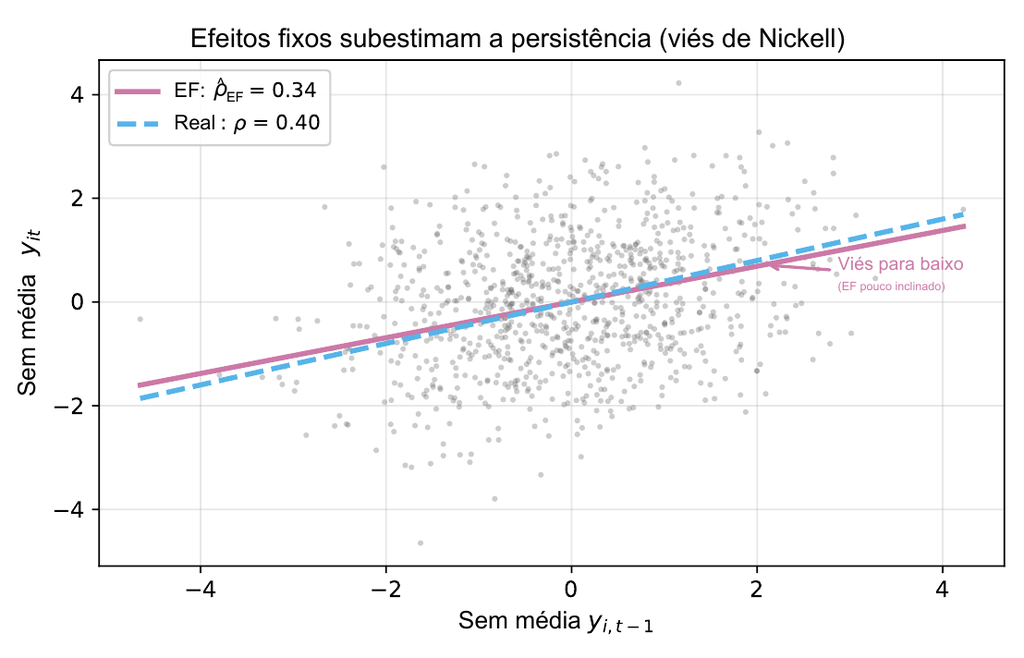

Figura 4: Efeitos fixos: subestimação da persistência na simulação. O estimador de efeitos fixos produz $\hat\rho_{\mathrm{EF}}\approx 0{,}34$, abaixo do valor verdadeiro $\rho=0{,}40$. A transformação *within* elimina $\alpha_i$, mas a variável dependente defasada transformada permanece endógena, produzindo o viés de Nickell.

## O viés de Nickell diminui quando $T$ cresce

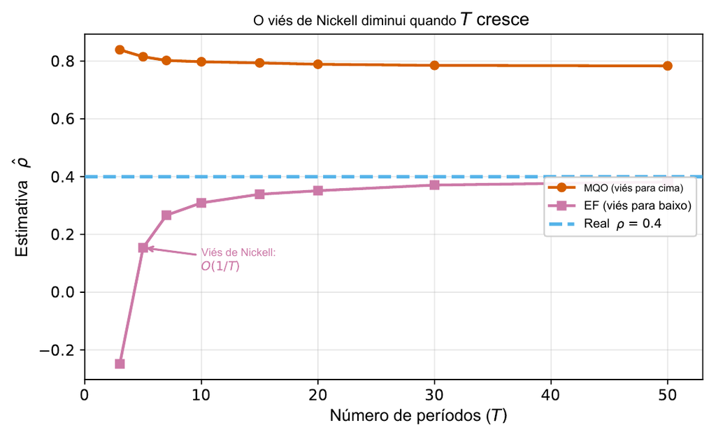

Figura 5: Estimativas de persistência por MQO e efeitos fixos conforme o número de períodos.

## O viés de Nickell diminui quando $T$ cresce

- O viés do estimador de **efeitos fixos** é de ordem $O(1/T)$ (aproximadamente proporcional a $1/T$): pode ser expressivo em painéis curtos ($T=3$ ou $T=5$), mas diminui quando $T$ cresce.
- Na simulação, a estimativa do **MQO ingênuo** varia pouco com $T$. Aumentar o número de períodos não elimina os problemas decorrentes das variáveis omitidas.

## Estimadores viesados

Na nossa simulação, as estimativas ficam em lados opostos do valor verdadeiro:

| Estimador | $\hat\rho$ | Resultado |
| --- | --- | --- |
| MQO ingênuo | $\approx 0{,}69$ | Superestima $\rho$ |
| Efeitos fixos | $\approx 0{,}34$ | Subestima $\rho$ |
| **Valor verdadeiro** | **$0{,}40$** |  |

Os métodos apresentam problemas diferentes:

- O MQO ingênuo omite variáveis relevantes;
- os efeitos fixos removem $\alpha_i$ (a heterogeneidade individual não observada, suposta constante), mas apresentam o viés de Nickell.

**Heurística de Bond (2002):** em modelos dinâmicos AR(1) simples, as estimativas de EF e MQO funcionam como referências **inferior e superior** para $\rho$.

Espera-se que uma estimativa **VI/GMM** plausível esteja entre elas:

$$\hat\rho_{\mathrm{EF}}<\hat\rho_{\mathrm{VI/GMM}}<\hat\rho_{\mathrm{MQO}}$$

**Há uma saída?**

## Dois problemas, uma estratégia

Onde estamos:

- **Problema 1:** o MQO ingênuo omite $\alpha_i$ e $\mathrm{invest}_{it}$ $\Longrightarrow$ superestima $\rho$ na simulação.
- **Problema 2:** efeitos fixos eliminam $\alpha_i$, mas a variável dependente defasada transformada permanece endógena $\Longrightarrow$ viés de Nickell.

E se eliminássemos $\alpha_i$ de outra maneira?

As primeiras diferenças também removem $\alpha_i$, mas não resolvem, isoladamente, a endogeneidade: $\Delta y_{i,t-1}$ está correlacionada com $\Delta\varepsilon_{it}$.

**A estratégia:**

1. Eliminar $\alpha_i$ por primeiras diferenças, em vez de remover as médias.
2. Utilizar **defasagens anteriores de $y$ como instrumentos** para $\Delta y_{i,t-1}$, sob hipóteses apropriadas.

$\Longrightarrow$ Essa é a ideia central do estimador de Arellano–Bond (Arellano e Bond, 1991).

GMM em Diferenças de Arellano e Bond (1991)

## Passo 1: primeiras diferenças para eliminar $\alpha_i$

Em vez de remover as médias (o que cria o viés de Nickell), tome primeiras diferenças do modelo:

$$\Delta y_{it}=\rho\,\Delta y_{i,t-1}+\beta\,\Delta\mathrm{invest}_{it}+\Delta\varepsilon_{it}$$

em que $\Delta y_{it}=y_{it}-y_{i,t-1}$.

O efeito fixo $\alpha_i$ desapareceu (eliminado pelas diferenças). Mas ainda não podemos aplicar MQO a essa equação.

O que dá errado se tentarmos?

## MQO nos dados em primeiras diferenças

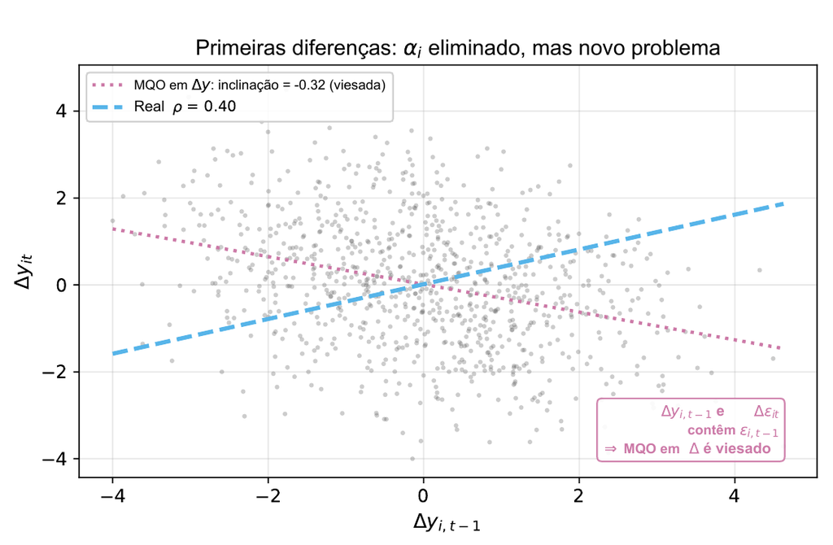

Figura 6: MQO em primeiras diferenças: inclinação estimada de −0,32, ante o valor verdadeiro de 0,40. MQO nos dados em diferenças fornece uma inclinação de $\approx -0,32$, muito errada ($\rho$ verdadeiro $=0,40$). As primeiras diferenças eliminaram $\alpha_i$, mas algo mais deu errado. O quê?

## O problema: $\Delta y_{i,t-1}$ e $\Delta\varepsilon_{it}$ compartilham um termo

Expanda os termos:

$$\begin{aligned}
\Delta y_{i,t-1}&=y_{i,t-1}-y_{i,t-2} &&\text{contém }\varepsilon_{i,t-1}\\
\Delta\varepsilon_{it}&=\varepsilon_{it}-\varepsilon_{i,t-1} &&\text{também contém }\varepsilon_{i,t-1}
\end{aligned}$$

$\Longrightarrow$ $\Delta y_{i,t-1}$ e $\Delta\varepsilon_{it}$ compartilham $\varepsilon_{i,t-1}$, portanto:

$$\operatorname{Cov}(\Delta y_{i,t-1},\Delta\varepsilon_{it})\neq0$$

MQO na equação em primeiras diferenças é inconsistente. Precisamos de um instrumento para $\Delta y_{i,t-1}$.

Qual variável está correlacionada com $\Delta y_{i,t-1}$, mas não com $\Delta\varepsilon_{it}$?

## Passo 2: usar $y_{i,t-2}$ como instrumento

A estratégia é utilizar $y_{i,t-2}$ como instrumento para $\Delta y_{i,t-1}$. Essa ideia, empregada por Anderson e Hsiao (1982), é ampliada por Arellano e Bond (1991).

Relevância: o instrumento precisa estar correlacionado com o regressor endógeno:

$$\operatorname{Cov}(y_{i,t-2},\Delta y_{i,t-1})\neq 0$$

- Essa correlação depende da dinâmica do modelo e não é garantida apenas pela definição de primeira diferença.

Validade (exogeneidade instrumental): o instrumento não pode estar correlacionado com o erro da equação diferenciada:

$$\mathrm{E}[y_{i,t-2}\,\Delta\varepsilon_{it}]=0$$

- Se os erros $\varepsilon_{it}$ forem choques não correlacionados com o passado de $y$ e sem correlação serial, $y_{i,t-2}$ não estará correlacionado com $\varepsilon_{it}$ nem com $\varepsilon_{i,t-1}$.

$\Longrightarrow$ Um instrumento precisa ser relevante e válido. Uma condição não garante a outra.

## O instrumento em ação

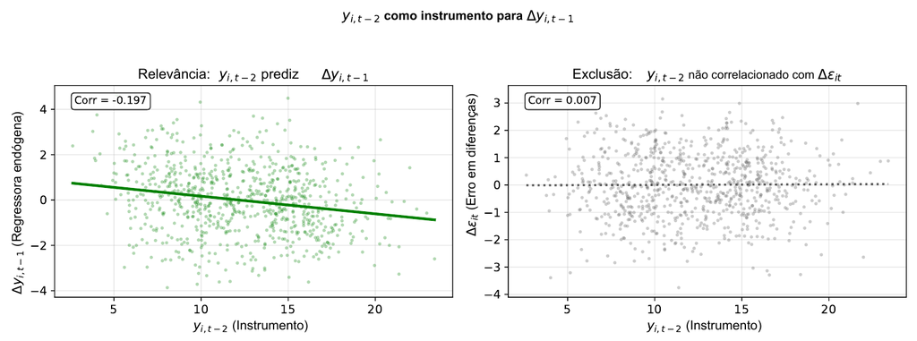

Figura 7: **Esquerda:** correlação negativa entre o instrumento $y_{i,t-2}$ e $\Delta y_{i,t-1}$, ilustrando sua relevância. **Direita:** correlação próxima de zero entre o instrumento e $\Delta\varepsilon_{it}$, compatível com sua exogeneidade na simulação.

## Identificação instrumental

### Modelo simplificado

Considere inicialmente o modelo dinâmico sem a variável investimento:

$$y_{it}=\rho y_{i,t-1}+\alpha_i+\varepsilon_{it}
\quad\Longrightarrow\quad
\Delta y_{it}=\rho\Delta y_{i,t-1}+\Delta\varepsilon_{it}$$

Defina $z_{it}=y_{i,t-2}$ como instrumento. Tomando a **covariância** dos dois lados da equação diferenciada com $z_{it}$:

$$\operatorname{Cov}(z_{it},\Delta y_{it})=\rho\operatorname{Cov}(z_{it},\Delta y_{i,t-1})+\operatorname{Cov}(z_{it},\Delta\varepsilon_{it})$$

Pela exogeneidade do instrumento:

$$\operatorname{Cov}(z_{it},\Delta\varepsilon_{it})=0$$

$\rightarrow$ O último termo desaparece da equação.

## Identificação de $\rho$ por variáveis instrumentais

Como o instrumento é válido, a equação anterior se reduz a:

$$\operatorname{Cov}(z_{it},\Delta y_{it})=\rho\operatorname{Cov}(z_{it},\Delta y_{i,t-1})$$

Se o instrumento também for relevante, então $\operatorname{Cov}(z_{it},\Delta y_{i,t-1})\neq0$. Podemos isolar $\rho$:

$$\boxed{\rho=\frac{\operatorname{Cov}(z_{it},\Delta y_{it})}{\operatorname{Cov}(z_{it},\Delta y_{i,t-1})}}$$

- Validade: elimina a covariância entre o instrumento e o erro.
- Relevância: permite dividir pela covariância entre o instrumento e o regressor endógeno.

Na amostra, substituímos as covariâncias populacionais pelas amostrais para estimar $\rho$ por variáveis instrumentais (VI).

## Condições de momento no modelo com investimento

Retomando o modelo da simulação, em primeiras diferenças:

$$\Delta y_{it}=\rho\,\Delta y_{i,t-1}+\beta\,\Delta\mathrm{invest}_{it}+\Delta\varepsilon_{it}$$

Níveis defasados como instrumentos: para $s=1,\ldots,t-2$, a validade de $y_{i,s}$ implica:

$$\mathrm{E}\left[y_{i,s}\left(\Delta y_{it}-\rho\,\Delta y_{i,t-1}-\beta\,\Delta\mathrm{invest}_{it}\right)\right]=0$$

Investimento estritamente exógeno: sob essa hipótese da simulação, sua primeira diferença também satisfaz:

$$\mathrm{E}[\Delta\mathrm{invest}_{it}\,\Delta\varepsilon_{it}]=0$$

Qual **método de estimação** estudado na Aula 4 **permite combinar essas condições de momento** para estimar $\rho$ e $\beta$?

$\rightarrow$ Método Generalizado dos Momentos (GMM)!

## Ampliando o conjunto de instrumentos

Até aqui, utilizamos $y_{i,t-2}$ como instrumento para $\Delta y_{i,t-1}$. **E as defasagens mais antigas?**

Sob as mesmas hipóteses de validade, elas também podem ser utilizadas:

| Período | Instrumentos para $\Delta y_{i,t-1}$ |
| --- | --- |
| $t=3$ | $y_{i,1}$ |
| $t=4$ | $y_{i,1},\ y_{i,2}$ |
| $t=5$ | $y_{i,1},\ y_{i,2},\ y_{i,3}$ |
| $\vdots$ | $\vdots$ |
| $t=T$ | $y_{i,1},\ y_{i,2},\ \ldots,\ y_{i,T-2}$ |

Cada instrumento fornece uma condição de momento, que expressa sua ausência de correlação com o erro diferenciado:

$$\mathrm{E}[y_{i,s}\,\Delta\varepsilon_{it}]=0,
\qquad s=1,\ldots,t-2,\quad t=3,\ldots,T$$

$\rightarrow$ O número de instrumentos disponíveis cresce com $t$, fornecendo múltiplas condições de momento para a estimação.

## Método Generalizado dos Momentos (GMM)

Já identificamos as condições de momento para estimar os parâmetros $\boldsymbol{\theta}=(\rho,\beta)^\top$.

- **Na população:** as condições de momento são iguais a zero.
- **Na amostra:** quando há mais condições independentes que parâmetros, geralmente não conseguimos satisfazê-las todas exatamente.

**O GMM escolhe os parâmetros que minimizam a discrepância conjunta das condições de momento:**

$$\widehat{\boldsymbol{\theta}}=\arg\min_{\boldsymbol{\theta}}\;\widehat{\mathbf g}_N(\boldsymbol{\theta})^\top\mathbf W_N\widehat{\mathbf g}_N(\boldsymbol{\theta})$$

em que $\widehat{\mathbf g}_N$ reúne as condições de momento amostrais e $\mathbf W_N$ é a matriz de ponderação.

- GMM em uma etapa: utiliza uma matriz de ponderação inicial.
- GMM em duas etapas: atualiza essa matriz utilizando os resíduos da primeira estimação, buscando maior eficiência assintótica.

$\rightarrow$ Arellano–Bond: aplicação do GMM às equações em primeiras diferenças, utilizando níveis defasados como instrumentos.

## Especificação do GMM em diferenças

Arellano–Bond estima por GMM a equação em primeiras diferenças:

$$\Delta y_{it}
=
\rho\,\Delta y_{i,t-1}
+
\beta\,\Delta\mathrm{invest}_{it}
+
\Delta\varepsilon_{it},
\qquad t=3,\ldots,T$$

Instrumentação: como $\Delta y_{i,t-1}$ está correlacionada com $\Delta\varepsilon_{it}$, utilizamos níveis defasados $y_{i1},\ldots,y_{i,t-2}$ como instrumentos.

Sua validade exige ausência de correlação serial em $\varepsilon_{it}$ e exogeneidade das condições iniciais em relação aos choques subsequentes.

Na simulação, $\mathrm{invest}_{it}$ é estritamente exógena. Assim, combinamos as seguintes condições de momento:

$$\begin{aligned}
\mathrm{E}[y_{is}\,\Delta\varepsilon_{it}] &= 0,
&& s\leq t-2 \\[6pt]
\mathrm{E}[\mathrm{invest}_{is}\,\Delta\varepsilon_{it}] &= 0,
&& \text{para todo }s,t
\end{aligned}$$

## Resultado

### Arellano–Bond aproxima-se do $\rho$ verdadeiro

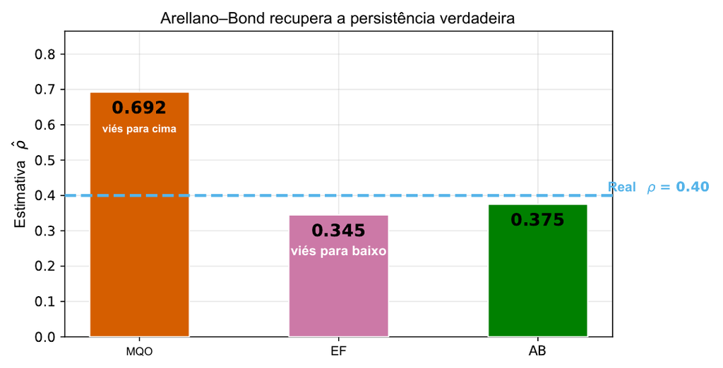

Figura 8: Na simulação, $\hat\rho_{\mathrm{AB}}\approx0{,}37$ aproxima-se do valor verdadeiro ($\rho=0{,}40$). O MQO ingênuo superestima ($0{,}69$), enquanto EF subestima ($0{,}34$).

$\rightarrow$ Arellano–Bond combina primeiras diferenças, que eliminam $\alpha_i$, com instrumentos em níveis defasados, que permitem lidar com a endogeneidade de $\Delta y_{i,t-1}$. Sob as hipóteses do modelo, o estimador é consistente quando $N\to\infty$ com $T$ fixo.

## Verificando as hipóteses de Arellano–Bond

Arellano–Bond depende da ausência de correlação serial nos erros em níveis $\varepsilon_{it}$ e da validade dos instrumentos. Dois grupos de testes usuais:

**1. Testes de autocorrelação AR(1) e AR(2)**

Aplicados aos erros em primeiras diferenças:

- AR(1): $H_0$: ausência de autocorrelação de primeira ordem. Espera-se **rejeitar**, pois a diferenciação induz essa correlação.
- AR(2): $H_0$: ausência de autocorrelação de segunda ordem. Espera-se **não rejeitar**, favorecendo a validade dos instrumentos.

**2. Testes de sobreidentificação de Sargan/Hansen**

Temos mais instrumentos que o estritamente necessário. Os testes verificam se suas **condições de momento são conjuntamente compatíveis** com o modelo.

- **$H_0$:** as restrições de sobreidentificação são válidas (Se os instrumentos fornecem informações incompatíveis, os testes podem rejeitar essa hipótese).

$\rightarrow$ **Apresente ambos os grupos de testes.** Se AR(2) for significativo ou Sargan/Hansen rejeitar, as hipóteses de Arellano–Bond ficam em dúvida.

## Diagnósticos

Na simulação, os erros $\varepsilon_{it}$ são independentes ao longo do tempo e os instrumentos satisfazem as condições de validade. **Quais resultados esperamos dos testes?**

| Teste | $H_0$ | Resultado esperado | Interpretação |
| --- | --- | --- | --- |
| AR(1) em $\Delta\varepsilon$ | Ausência de AR(1) | **Rejeitar** | Autocorrelação esperada pela diferenciação |
| AR(2) em $\Delta\varepsilon$ | Ausência de AR(2) | **Não rejeitar** | Favorável à validade dos instrumentos |
| Sargan/Hansen | Restrições de sobreidentificação válidas | **Não rejeitar** | Favorável à validade da especificação instrumental |

Como conhecemos o processo gerador dos dados, sabemos que as hipóteses de Arellano–Bond são satisfeitas. Os resultados da tabela são os **esperados** para essa simulação.

$\Longrightarrow$ Em aplicações reais, **apresente os valores-p de AR(1), AR(2) e Sargan/Hansen** junto às estimativas. Rejeições de AR(2) ou Sargan/Hansen exigem investigar as hipóteses do modelo.

## Quando Arellano–Bond enfrenta dificuldades?

Arellano–Bond utiliza níveis defasados como instrumentos na equação em primeiras diferenças. Além de válidos, esses instrumentos precisam ser relevantes.

**Em quais situações os instrumentos podem ser fracos?**

- Persistência elevada ($\rho\approx1$): os níveis defasados podem explicar pouco as variações $\Delta y_{i,t-1}$.
- Heterogeneidade individual acentuada: quando a variância de $\alpha_i$ é grande em relação à de $\varepsilon_{it}$, os níveis refletem predominantemente diferenças permanentes entre indivíduos.

$\Longrightarrow$ Instrumentos fracos podem produzir estimativas imprecisas e com viés importante em amostras finitas.

Acrescentar mais defasagens não resolve necessariamente o problema, pois elas também podem ser instrumentos fracos.

**Como obter novas condições de momento para fortalecer a estimação?**

GMM em sistema de Blundell e Bond (1998)

## GMM em sistema

### Visão geral do método

Quando a variável dependente é muito persistente, o GMM em diferenças pode apresentar instrumentos fracos.

O GMM em sistema combina duas equações do mesmo modelo:

- Equação em diferenças: utiliza níveis defasados como instrumentos.
- Equação em níveis: utiliza diferenças defasadas como instrumentos.

As duas equações são utilizadas **conjuntamente pelo GMM**, para estimar **um único conjunto de parâmetros**.

- **Vantagem:** os instrumentos adicionais podem melhorar a precisão das estimativas, especialmente quando a persistência é elevada.
- **Exigência:** sua validade depende de condições de momento adicionais, relacionadas às condições iniciais do processo.

$\rightarrow$ O GMM em sistema **amplia o conjunto de informações utilizadas na estimação**, mas exige hipóteses adicionais para justificar os novos instrumentos.

## Especificação do GMM em sistema

### Duas equações para o mesmo modelo

O GMM em sistema utiliza duas representações do modelo dinâmico, com os mesmos parâmetros $\rho$ e $\beta$.

Equação em primeiras diferenças:

$$\Delta y_{it}=\rho\,\Delta y_{i,t-1}
+\beta\,\Delta\mathrm{invest}_{it}
+\Delta\varepsilon_{it}$$

Equação em níveis:

$$y_{it}=\rho\,y_{i,t-1}
+\beta\,\mathrm{invest}_{it}
+\alpha_i+\varepsilon_{it}$$

- **Diferenças:** o efeito individual $\alpha_i$ é eliminado.
- **Níveis:** o efeito individual permanece no erro da equação.

$\rightarrow$ As duas equações fornecem condições de momento para uma única estimação GMM dos parâmetros $\rho$ e $\beta$.

## Instrumentação no GMM em sistema

### Instrumentos para a variável dependente defasada

As duas equações utilizam instrumentos diferentes para o termo autorregressivo:

| Equação | Variável instrumentalizada | Instrumentos |
| --- | --- | --- |
| Diferenças | $\Delta y_{i,t-1}$ | $y_{i,t-2},y_{i,t-3},\ldots$ |
| Níveis | $y_{i,t-1}$ | $\Delta y_{i,t-1}$ |

**Exemplo: no período $t=4$**

- **Diferenças:** para instrumentalizar $\Delta y_{i3}$, podemos utilizar $y_{i2}$ e $y_{i1}$.
- **Níveis:** para instrumentalizar $y_{i3}$, utilizamos $\Delta y_{i3}=y_{i3}-y_{i2}$.

$\rightarrow$ A equação em níveis introduz novos instrumentos, baseados nas variações passadas de $y$.

**Por que essas variações podem ser instrumentos válidos se $\alpha_i$ permanece no erro da equação em níveis?**

## Validade dos instrumentos em níveis

### Exemplo: período $t=4$

Retomando a equação em níveis:

$$y_{i4}=\rho y_{i3}+\beta\,\mathrm{invest}_{i4}
+\underbrace{\alpha_i+\varepsilon_{i4}}_{\text{erro}}$$

Para instrumentalizar $y_{i3}$, utilizamos a variação passada $\Delta y_{i3}=y_{i3}-y_{i2}$.

Um instrumento precisa satisfazer duas exigências:

- Relevância: estar relacionado com a variável instrumentalizada, $y_{i3}$.
- Exogeneidade: não estar correlacionado com o erro $\alpha_i+\varepsilon_{i4}$.

A condição de exogeneidade pode ser expressa como:

$$\boxed{\mathrm{E}[\Delta y_{i3}(\alpha_i+\varepsilon_{i4})]=0}$$

**O desafio:** o efeito individual $\alpha_i$ permanece no erro da equação em níveis. Como justificar essa condição?

## Condições de momento adicionais

Para utilizar $\Delta y_{i,t-1}$ como instrumento na equação em níveis, exigimos, para $t=3,\ldots,T$:

$$\begin{aligned}
\mathrm{E}[\Delta y_{i,t-1}(\alpha_i+\varepsilon_{it})] &= 0\\
\mathrm{E}[\Delta y_{i,t-1}\varepsilon_{it}]
+\mathrm{E}[\Delta y_{i,t-1}\alpha_i] &= 0
\end{aligned}$$

- **Choque idiossincrático:** o primeiro termo é nulo sob as hipóteses já adotadas para $\varepsilon_{it}$.
- **Efeito individual:** o segundo termo exige uma hipótese adicional:

$$\boxed{\mathrm{E}[\Delta y_{i,t-1}\alpha_i]=0}$$

$\rightarrow$ As variações passadas de $y$ não devem estar sistematicamente associadas aos **efeitos individuais**.

**Quando essa hipótese é plausível?**

## Média individual de longo prazo

### O papel do efeito individual

Considere o modelo simplificado, **sem investimento**, com $|\rho|<1$ e choques de média condicional zero:

$$y_{it}=\rho y_{i,t-1}+\alpha_i+\varepsilon_{it}$$

Cada indivíduo possui uma média de longo prazo $\mu_i$, em torno da qual sua variável $y$ tende a oscilar.

Nesse nível, a variação esperada de $y$ é nula:

$$\mu_i=\rho\mu_i+\alpha_i
\quad\Longrightarrow\quad
\boxed{\mu_i=\frac{\alpha_i}{1-\rho}}$$

**Exemplo:** com $\rho=0{,}8$, considere duas empresas:

- **Empresa A:** $\alpha_A=2 \;\Rightarrow\; \mu_A=10$.
- **Empresa B:** $\alpha_B=4 \;\Rightarrow\; \mu_B=20$.

$\rightarrow$ Mesmo com o mesmo $\rho$, empresas com **efeitos individuais diferentes** podem apresentar médias de longo prazo distintas.

## Ajustamento à média individual

### O papel da distância à média

A partir do modelo anterior, podemos escrever:

$$\Delta y_{it}=(1-\rho)(\mu_i-y_{i,t-1})+\varepsilon_{it}$$

Como $1-\rho>0$, a **variação esperada de $y$** depende de sua distância à média individual:

- Se $y_{i,t-1}<\mu_i$, a variação esperada é **positiva**.
- Se $y_{i,t-1}>\mu_i$, a variação esperada é **negativa**.

**Exemplo:** para a empresa A, com $\mu_A=10$ e $\rho=0{,}8$:

- Se $y_{A,t-1}=5$, a variação esperada é $0{,}2(10-5)=+1$.
- Se $y_{A,t-1}=15$, a variação esperada é $0{,}2(10-15)=-1$.

$\rightarrow$ A variável tende a se aproximar de sua própria média de longo prazo, embora os choques possam provocar oscilações.

**Mas o que acontece quando os indivíduos começam em posições diferentes em relação às suas médias?**

## Condições iniciais: dois cenários

### Níveis e desvios iniciais

O desvio inicial é a diferença entre o valor inicial de $y$ e sua média individual de longo prazo:

$$\boxed{d_{i1}=y_{i1}-\mu_i}$$

**Exemplo:** retomando as empresas A e B, com $\mu_A=10$ e $\mu_B=20$:

| Situação | Empresa A: $(y_{A1},d_{A1})$ | Empresa B: $(y_{B1},d_{B1})$ |
| --- | --- | --- |
| Mesmo nível inicial | $(10,\;0)$ | $(10,\;-10)$ |
| Mesmo desvio inicial | $(8,\;-2)$ | $(18,\;-2)$ |

- **Mesmo nível inicial:** os desvios são diferentes e estão associados às médias individuais.
- **Mesmo desvio inicial:** as empresas começam à mesma distância de suas respectivas médias.

$\rightarrow$ Para avaliar as condições iniciais, importa saber **como os desvios se relacionam com os efeitos individuais**.

## Hipótese sobre as condições iniciais

No modelo AR(1), a primeira variação depende do desvio inicial $d_{i1}=y_{i1}-\mu_i$:

$$\Delta y_{i2}=-(1-\rho)d_{i1}+\varepsilon_{i2}$$

Se o desvio inicial estiver correlacionado com $\alpha_i$, as variações de $y$ também poderão estar, comprometendo os instrumentos da equação em níveis.

Hipótese adicional de Blundell e Bond (1998):

$$\boxed{\mathrm{E}[\alpha_i d_{i1}]=0}$$

Sob $\mathrm{E}[\alpha_i]=0$, os desvios iniciais não estão correlacionados com os efeitos individuais.

Sob as demais hipóteses do modelo, essa restrição implica $\mathrm{E}[\alpha_i\Delta y_{i,t-1}]=0$, para $t\geq 3$.

$\rightarrow$ **As diferenças defasadas podem instrumentar a equação em níveis**, mesmo que os indivíduos ainda não estejam em suas médias de longo prazo.

## Desempenho do GMM em sistema

### Viés nas simulações de Blundell e Bond (1998)

Blundell e Bond (1998) realizaram **1.000 simulações** de um modelo AR(1) estacionário, com $N=200$ e $T=4$, comparando estimadores GMM em duas etapas. Em cada simulação, os estimadores Dif e Sys<sup>1</sup> produziram uma estimativa de $\rho$.

**Quanto mais próxima a média das estimativas estiver do valor verdadeiro de $\rho$, menor o viés.**

| $\rho$ verdadeiro | Média $\hat\rho$ (Dif) | Média $\hat\rho$ (Sys) |
| --- | --- | --- |
| 0,30 | 0,2919 | 0,3092 |
| **0,80** | **0,6362** | **0,8050** |

Fonte: Blundell e Bond (1998), Tabela 2(a).

- **Persistência baixa ($\rho=0{,}30$):** ambos apresentam médias próximas do valor verdadeiro.
- **Persistência elevada ($\rho=0{,}80$):** Dif subestima substancialmente $\rho$, enquanto Sys apresenta uma média muito próxima do valor verdadeiro.

$\rightarrow$ Com **persistência elevada**, o GMM em sistema apresentou viés muito menor nessas simulações.

[^1]: Dif = GMM em diferenças; Sys = GMM em sistema.

## Precisão do GMM em sistema

### Dispersão das estimativas nas simulações

Além do viés, importa a precisão: nas 1.000 simulações de Blundell e Bond (1998), o desvio-padrão (DP) das estimativas de $\rho$ aproxima o erro-padrão verdadeiro de cada estimador. Quanto menor o DP, maior a precisão.

| $\rho$ verdadeiro | DP de $\hat\rho$ (Dif) | DP de $\hat\rho$ (Sys) |
| --- | --- | --- |
| 0,30 | 0,1270 | 0,0833 |
| **0,80** | **0,5219** | **0,1195** |

*Fonte: Blundell e Bond (1998), Tabela 2(a).*<sup>1</sup>

- **Persistência baixa:** Sys apresenta menor dispersão das estimativas.
- **Persistência elevada:** o DP de Sys é aproximadamente 77% menor que o de Dif.

$\rightarrow$ O **GMM em sistema apresenta maior precisão**, especialmente quando a persistência é elevada.

[^2]: Dif = GMM em diferenças; Sys = GMM em sistema.

## Diagnósticos do GMM em sistema

### Validade dos instrumentos

Os diagnósticos estudados no GMM em diferenças também são utilizados no GMM em sistema:

- AR(1): espera-se detectar autocorrelação de primeira ordem nos erros em diferenças.
- AR(2): espera-se não rejeitar a ausência de autocorrelação de segunda ordem.
- Hansen (J): testa a validade conjunta das restrições de sobreidentificação.

Teste de diferença de Hansen (*difference-in-Hansen*)

Permite avaliar especificamente os **instrumentos adicionais da equação em níveis**, comparando as estatísticas de Hansen com e sem esse conjunto de instrumentos.

- **$H_0$:** as condições de momento adicionais são válidas, supondo válidas as demais restrições.
- **Rejeição de $H_0$:** evidência contrária à validade dos instrumentos adicionais.
- **Não rejeição de $H_0$:** os resultados são compatíveis com a validade dessas condições.

$\rightarrow$ O teste de diferença de Hansen permite avaliar as **novas restrições que distinguem o GMM em sistema do GMM em diferenças**.

## Proliferação de instrumentos

No GMM em diferenças, cada período permite utilizar mais níveis defasados de $y$ como instrumentos.

**Sem agrupamento**, cada combinação de período e defasagem gera uma **coluna distinta na matriz de instrumentos**.

**Exemplo: $T=4$**, utilizando todas as defasagens válidas:

| Período | Instrumentos | Colunas |
| --- | --- | --- |
| $t=3$ | $y_{i1}$ | 1 |
| $t=4$ | $y_{i1},\;y_{i2}$ | 2 |

**Total: 3 colunas.** O mesmo $y_{i1}$ ocupa colunas distintas por ser utilizado em períodos diferentes.

Com $T=8$: $1+2+\cdots+6=21$ colunas.

Em geral: $J_y^{\mathrm{Dif}}=(T-1)(T-2)/2$.

O GMM em sistema acrescenta instrumentos para a equação em níveis.

Riscos do excesso (Roodman, 2009a): maior viés por sobreajuste e menor poder dos testes de Hansen.

## Controle da proliferação de instrumentos

Duas estratégias discutidas por Roodman (2009b) e Roodman (2009a) permitem reduzir o conjunto instrumental.

1. Limitar as defasagens: utilizar apenas algumas defasagens válidas, por exemplo, somente $y_{i,t-2}$.
2. Agrupar instrumentos (*collapse*): reunir em uma coluna os instrumentos com a mesma distância de defasagem, utilizados em períodos diferentes.

**Exemplo:** $T=8$, considerando apenas os instrumentos de $y$ no GMM em diferenças.

| Configuração | Colunas | Critério |
| --- | --- | --- |
| Sem restrições | **21** | Por período e defasagem |
| Apenas $y_{i,t-2}$ | **6** | Uma por período |
| Apenas *collapse* | **6** | Uma por distância de defasagem |
| Ambas as estratégias | **1** | Defasagem 2, agrupada |

$\rightarrow$ Limitar defasagens reduz as distâncias utilizadas, collapse reúne instrumentos de períodos diferentes. As estratégias podem ser combinadas.

## Sensibilidade ao conjunto de instrumentos

Após limitar defasagens e/ou aplicar *collapse*, **reestime o mesmo modelo** com conjuntos instrumentais menores.

**Compare os resultados das diferentes especificações:**

- **Instrumentos:** número total utilizado em cada estimação.
- **Estimativas:** mudanças nos coeficientes e erros-padrão.
- **Diagnósticos:** valores-p dos testes AR(2), Hansen e diferença de Hansen, quando aplicáveis.

$\rightarrow$ Estimativas sensíveis à redução dos instrumentos ou rejeições nos testes de diagnóstico são sinais de possíveis problemas na especificação.

## GMM em sistema

### Benefícios e exigências

O GMM em sistema acrescenta condições de momento ao GMM em diferenças, ampliando as possibilidades de instrumentação.

- Ganhos potenciais: menor viés e maior precisão, especialmente quando a variável dependente apresenta elevada persistência.
- Hipóteses adicionais: a validade dos novos instrumentos depende de restrições sobre as condições iniciais e sua relação com os efeitos individuais.
- **Avaliação da especificação:** examinar os testes de diagnóstico, controlar a proliferação de instrumentos e avaliar a sensibilidade das estimativas.

$\rightarrow$ O GMM em sistema não é automaticamente superior: seus benefícios dependem da plausibilidade das hipóteses adicionais e da escolha adequada dos instrumentos.

Estrutura de decisão

## Fluxograma de decisão

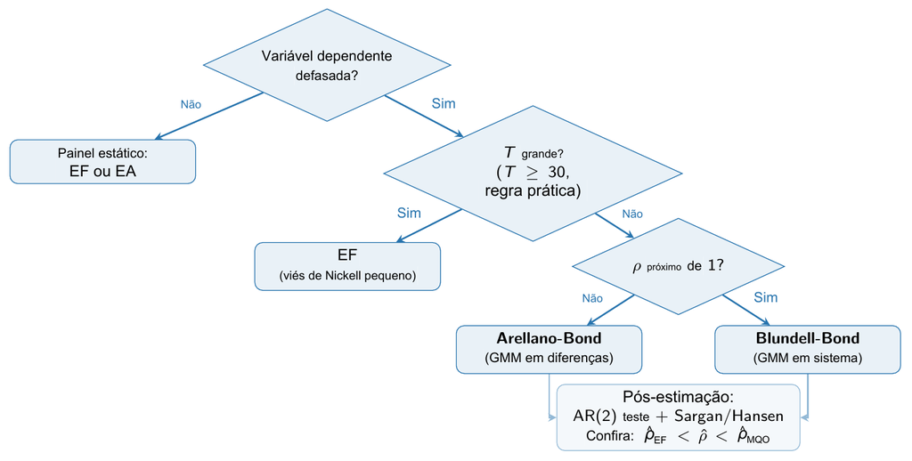

Figura 9: Fluxograma de escolha do estimador e dos diagnósticos em modelos dinâmicos de painel. Verifique se $y_{i,t-1}$ está no modelo; se $T$ for pequeno, escolha AB ou BB com base na persistência; sempre execute os diagnósticos pós-estimação.

Resumo

## Resumo

No painel simulado de **50 países**, buscamos estimar a persistência do crescimento do PIB ($\rho=0{,}40$).

1. MQO combinado: ignora a heterogeneidade individual $\alpha_i$, confundindo diferenças entre países com persistência temporal. No exemplo, superestimou $\rho$.
2. Efeitos fixos (EF): eliminam $\alpha_i$, mas a transformação *within* gera correlação entre o regressor defasado e o erro transformado (viés de Nickell). No exemplo, subestimou $\rho$.
3. Arellano–Bond: elimina $\alpha_i$ por primeiras diferenças e utiliza níveis defasados como instrumentos, sob condições de momento válidas. A persistência elevada pode enfraquecê-los.
4. Blundell–Bond: acrescenta uma equação em níveis, com instrumentos em diferenças. Pode reduzir o viés e aumentar a precisão, mas exige hipóteses adicionais.

**Verificação de plausibilidade Bond (2002):** no modelo dinâmico simples, espera-se que uma estimativa GMM consistente esteja, aproximadamente, entre as estimativas de EF e MQO:

$$\hat\rho_{\mathrm{EF}} < \hat\rho_{\mathrm{GMM}} < \hat\rho_{\mathrm{MQO}}$$

$\rightarrow$ A **escolha do estimador** exige considerar a endogeneidade, a validade dos instrumentos e os resultados dos diagnósticos.

Atividade 5

## Descrição da Atividade 5

**Aplicação:** persistência do endividamento de empresas norte-americanas, utilizando os dados `Invest1993` de Hansen (2022) (1.962 empresas, 1960–1991).

$$D_{it} = \rho D_{i,t-1} + \alpha_i + \varepsilon_{it}$$

- **Estimação em R:** comparar MQO combinado, efeitos fixos, GMM em diferenças (Arellano–Bond) e GMM em sistema (Blundell–Bond), utilizando o pacote `plm`.
- **Diagnósticos econométricos:** examinar os testes AR(1), AR(2), J de sobreidentificação e a quantidade de instrumentos.
- **Exercício:** responder a quatro questões sobre persistência do endividamento, limitações dos estimadores, instrumentos e escolha fundamentada do estimador GMM.

$\rightarrow$ **Orientação:** apresentar respostas concisas e fundamentadas nos resultados da atividade. Não são necessárias novas estimações.

## Referências

ANDERSON, T. W.; HSIAO, C. Formulation and Estimation of Dynamic Models Using Panel Data. **Journal of Econometrics**, v. 18, n. 1, p. 47–82, 1982.

ARELLANO, M.; BOND, S. [Some Tests of Specification for Panel Data: Monte Carlo Evidence and an Application to Employment Equations](https://doi.org/10.2307/2297968). **The Review of Economic Studies**, v. 58, n. 2, p. 277–297, 1991.

BALTAGI, B. H. **[Econometric Analysis of Panel Data](https://doi.org/10.1007/978-3-030-53953-5)**. 6. ed. Cham: Springer, 2021.

BLUNDELL, R.; BOND, S. Initial Conditions and Moment Restrictions in Dynamic Panel Data Models. **Journal of Econometrics**, v. 87, n. 1, p. 115–143, 1998.

BOND, S. R. [Dynamic Panel Data Models: A Guide to Micro Data Methods and Practice](https://doi.org/10.1007/s10258-002-0009-9). **Portuguese Economic Journal**, v. 1, n. 2, p. 141–162, 2002.

CROISSANT, Y.; MILLO, G. **[Panel Data Econometrics with R](https://doi.org/10.1002/9781119504641)**. [s.l.] John Wiley & Sons, 2018.

HANSEN, B. E. **Econometrics**. Princeton, NJ: Princeton University Press, 2022.

NICKELL, S. [Biases in Dynamic Models with Fixed Effects](https://doi.org/10.2307/1911408). **Econometrica**, v. 49, n. 6, p. 1417–1426, 1981.

ROODMAN, D. [How to Do xtabond2: An Introduction to Difference and System GMM in Stata](https://doi.org/10.1177/1536867X0900900106). **The Stata Journal**, v. 9, n. 1, p. 86–136, b2009.

___. [A Note on the Theme of Too Many Instruments](https://doi.org/10.1111/j.1468-0084.2008.00542.x). **Oxford Bulletin of Economics and Statistics**, v. 71, n. 1, p. 135–158, a2009.